# Tarea 1 - Backpropagation

Exercise done by Cedric Prieels for the Machine Learning I class.

The main goal of this exercise is to generalize a backpropagation function given as an example in order to add a hidden layer beteen the input and the output layers. When then need to apply this function to an example of circular classification to see if it actually words.

First, we will write an easy example showing how things work without any hidden layer. Then, we will manually add an hidden layer of a variable number of neurons in the second part of this exercise, while a generalization to a variable number of hiden layers will finally be presented.

## Without hidden layers

Let's first of all open our data, contained in the circle.csv file, and plot it to see what it looks like. as we can see, we have 100 observations following a circular distribution and corresponding to two classes, plotted either red or black.

1. 100

2. 2

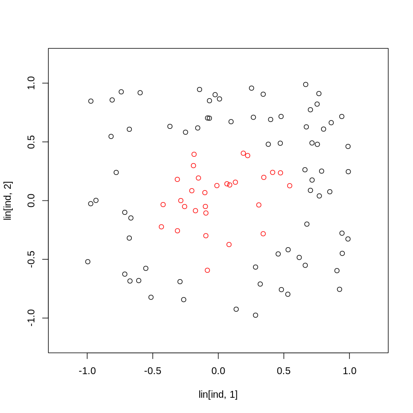

```r
lin<-read.csv("circle.csv",header = F)

a<-as.matrix(lin[,-3])
b<-as.matrix(lin[,3])
dim(a) #We have 100 observations in this case

ind=which(lin[,3]==0)
plot(lin[ind,1],lin[ind,2],type="p",xlim=c(-1.2,1.2),ylim=c(-1.2,1.2))
lines(lin[-ind,1],lin[-ind,2],type="p",col="red")
```

Let's also define at this point the sigmoid activation function that will be used throughout this exercise.

```r
#Activation function f(\hat{B})
activation <- function(z) {
    1/(1 + exp(-z))
}
```

As done in class, the weights between the neurons of the different layers will first of all be inizialed randomly. Then, they will be updated in an optimal way using the backpropagation/gradient descient algorithm, as we will see later on. This gradient descent algorithm is performed several times (the epochs parameter of the funcion), using a step eta, which has to be changed in order to avoid reaching and getting stuck in a minimum local during this method.

```r
backprop <- function(a, b, epochs = 10, eta = 0.1) { #a is the input, b the output

    a <- cbind(a,rep(1,nrow(a))) #To include the bias: we add as many 1 as needed and we concatenate to the input neurons

    neurons <- c(ncol(a),ncol(b)) #Only an input and an output layer for now
    #We define a random set of weights to start
    Wold <- matrix(data = runif(prod(neurons), min = -1, max = 1), nrow = neurons[2], ncol = neurons[1])

    errors = c() #We also keep the errors squared in order to plot them

    for (j in 1:epochs) {

        #Let's propagate the values of the neurons until reaching the output
        #The output is then obtained by multiplying a by the transpose of the matrix of the weights and activating the result
        bout <- activation(a %*% t(Wold)) #The transpose has to be used for dimension purposes
        error <- bout-b
        delta <- error*bout*(1-bout) #This is an extremly important parameters which will come back many times

        #Update the weights
        Wnew <- Wold - eta * t(delta)%*%a #According to the formula seen in class
        Wold <- Wnew #Getting ready to start again the loop for the next epoch

        errors[j] <- sum((error)^2) #Let's actually use the square of the difference between the output obtained and the actual output for the error in this exercise
        #print(paste("Error for epoch", j, " = ", sum(resid <- (error)^2)))

    }

    return(errors)
}
```

Now that the function has been designed, let's apply it to our particular data. By plotting the error square, we clearly see that this error decreases with respect to the number of epochs, until reaching a stable value after a few epochs only. Of course, of we choose eta too large then we just miss the minimum to go back to the other side and getting once again a higher error value, so the choice has to made carefully.

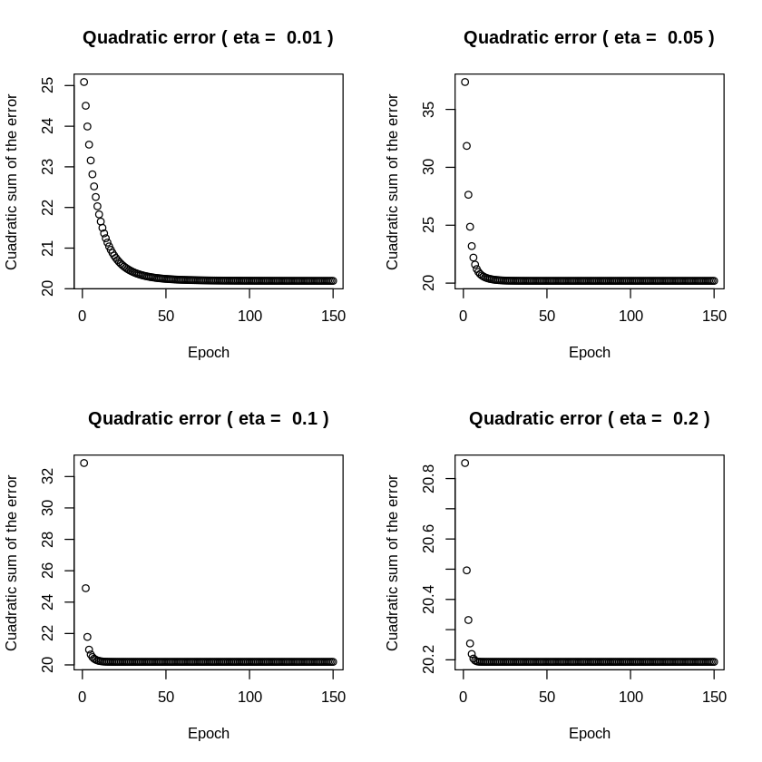

```r
set.seed(1) #To always get the same results

etas <- c(0.01, 0.05, 0.1, 0.2) #Let's use different eta values and plot the error
par(mfrow=c(2,2))

for(i in 1:length(etas)){
    errors <- backprop(a, b, epochs = 150, eta = etas[i])
    plot(errors, main=paste("Quadratic error ( eta = ", etas[i], ")"), xlab="Epoch", ylab="Cuadratic sum of the error")
}
```

We clearly see that the error keeps decreasing for these eta values, and reaches a minimum quite rapidly. Let's now repeat the same exercise by adding an additional layer between the input and the output.

## With one hidden layer

The hidden layer we are going to add will have a variable number of neurons, h. Let's then define a new function called backprop_one, taking h as an additional argument and updating the weights accordingly. Of course, in this case, we wil need to define two sets of weights: wXtoA, from the input to the hidden layer, and WAtoB, fron the hidden layer to the output.

```r
backprop_one <- function(x, b, h = 5, epochs = 10, eta = 0.1) {
    #In this case, x is the input, a the values of the hidden layer and b the output, to follow the notation from the class
    #h is now the number of hidden neurons in the hidden layer, which defaults to 5

    #Let's initialize our matrices and lists
    x <- cbind(x,rep(1,nrow(x))) #Include the bias to the input, only once at the beginning
    neurons <- c(ncol(x), h, ncol(b)) #We add the hidden neurons h in the middle of this vector

    #Let's now define wXtoH the random weights of the input to the hidden layer, and wHtoB the second set of weights
    wXtoA <- matrix(data = runif(prod(neurons), min = -1, max = 1), nrow = neurons[2], ncol = neurons[1]) #Random set of weights to start
    wAtoB <- matrix(data = runif(prod(neurons), min = -1, max = 1), nrow = neurons[3], ncol = neurons[2])

    errors = c() #Keep the errors to plot them

    for (j in 1:epochs) {

        #Let's compute the values of the different layers for these weights
        a <- activation(x %*% t(wXtoA))
        bout <- activation(a %*% t(wAtoB))

        #Let's compute the different parameters we will need later on, such as delta
        error <- bout-b
        delta <- error*bout*(1-bout)

        #Now, let's update the different weights using the backpropagation method
        wAtoB <- wAtoB - eta * t(delta) %*% a

        #The second weight is a bit harder to compute as it depends on many different facotrs, each with different dimensions
        fac1 <- delta %*% wAtoB
        fac2 <- fac1 * (a*(1-a))
        fac3 <- t(fac2) %*% x

        wXtoA <- wXtoA - eta * fac3 #We need to take care of the dimensions here

        errors[j] <- sum((error)^2)

    }

    return(errors)
}
```

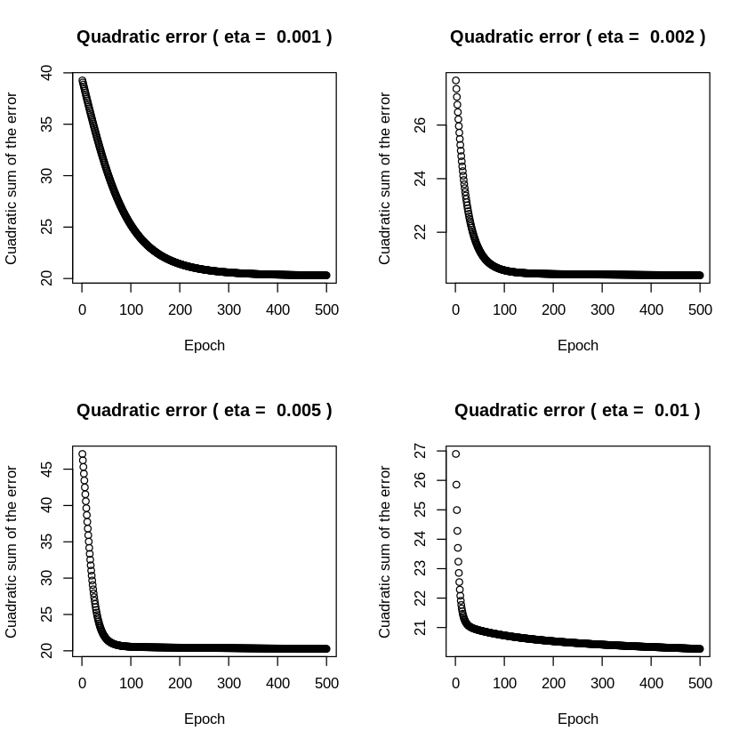

```r
set.seed(1) #To always get the same results

etas <- c(0.001, 0.002, 0.005, 0.01) #Let's use different eta values and plot the error (low values of eat since we are asked to use 500 epochs)
par(mfrow=c(2,2))

for(i in 1:length(etas)){
    errors <- backprop_one(a, b, h = 5, epochs = 500, eta = etas[i])
    plot(errors, main=paste("Quadratic error ( eta = ", etas[i], ")"), xlab="Epoch", ylab="Cuadratic sum of the error")
}
```

## With a variable number of hidden layers

Let's now repeat the same exercise considering the case where h is a vector of neurons, instead of a scalar. This will correspond to the case of multiple hidden layers put between the input and the output.

```r
backprop_multiple <- function(x, b, h = c(5, 5, 5), epochs = 10, eta = 0.1) {
    #In this case, x is the input and b the output, as before
    #h is now the number of hidden neurons in several hidden layers

    #Let's initialize our matrices and lists
    x <- cbind(x,rep(1,nrow(x))) #Include the bias to the input, only once at the beginning
    neurons <- c(ncol(x), h, ncol(b)) #We add the hidden neurons h in the middle of this list
    nLayers <- length(neurons) #The total number of layers

    #We will keep the values of all the different layers, not only the hidden layers ones, in a values list
    values <- list()
    values[[1]] <- x #The first layer is the input
    values[[nLayers]] <- b #The last layer is the output

    #Let's now define a list of random weights corresponding to the weights between the different layers
    weights <- list()
    for (i in 1:(nLayers-1)) { #If we have 4 total layers, we need to define 3 sets of weights
        weights[[i]] <- matrix(data = runif(prod(neurons), min = -1, max = 1), nrow = neurons[i+1], ncol = neurons[i])
    }

    #We will also keep the different delta parameters computed in a list
    delta <- list()

    errors = c() #Keep the errors to plot them

    for (j in 1:epochs) {

        #Let's compute the values for all the layers. We actually already know the value of the first one (input) and the last one (output)
        for (k in 2:(nLayers)) {
            values[[k]] <- activation(values[[k-1]] %*% t(weights[[k-1]]))
        }

        bout <- values[[nLayers]] #Estimated output value = value of the last layer
        error <- bout-b
        delta[[nLayers-1]] <- error*bout*(1-bout) #The first delta is computed out of the loop using the real value of b, which is not contained with the list values

        #Now we can loop backwards over the remaining layers to compute all the other deltas
        for (k in (nLayers-2):1) { #We expect to have nLayers-1 delta parameters, just as the weights
            factor <- delta[[k+1]] %*% weights[[k+1]] #Each delta is computed from the previous one and from the weights of the current layer
            delta[[k]] <- factor * (values[[k+1]]*(1-values[[k+1]]))
        }

        #Finally, let's update the different weights using the backpropagation method and the deltas just calculated
        for (k in 1:(nLayers-1)) { #We need nLayers-1 weights
            weights[[k]] <- weights[[k]] - eta * (t(delta[[k]]) %*% values[[k]])
        }

        errors[j] <- sum((error)^2) #The error is given by the difference between our output and the expected one, squared

    }

    return(errors)
}
```

Now that the code is ready, let's try to repeat the same exercise as before, by setting one hidden layer of 5 neurons. We get exactly the same results.

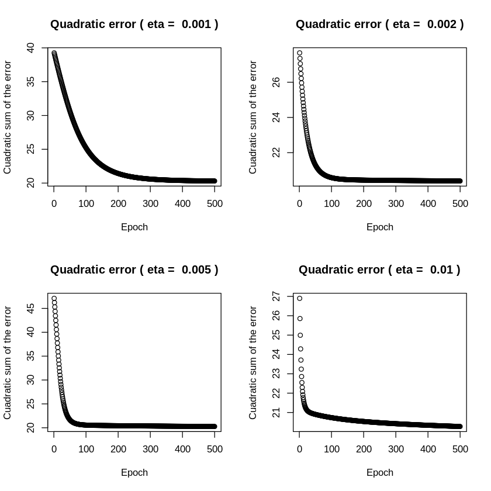

```r
set.seed(1) #To always get the same results

etas <- c(0.001, 0.002, 0.005, 0.01) #Let's use different eta values and plot the error (low values of eat since we are asked to use 500 epochs)
par(mfrow=c(2,2))

#This should give us exactly the same output as before
for(i in 1:length(etas)){
    errors <- backprop_multiple(a, b, h = c(5), epochs = 500, eta = etas[i])
    plot(errors, main=paste("Quadratic error ( eta = ", etas[i], ")"), xlab="Epoch", ylab="Cuadratic sum of the error")
}
```

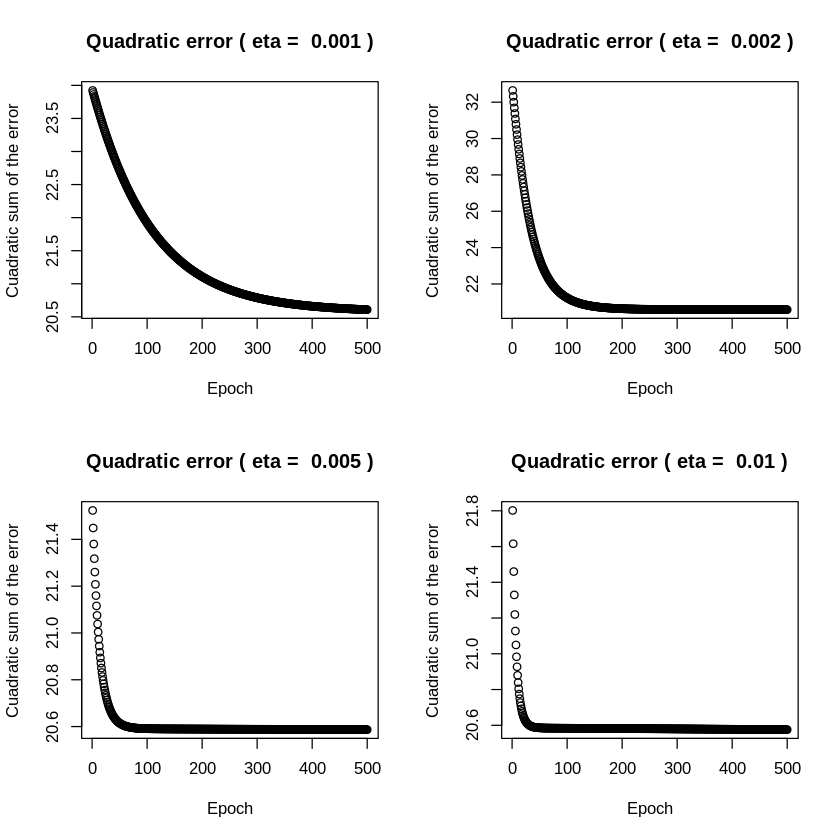

```r
#Now let's try adding more layers
etas <- c(0.001, 0.002, 0.005, 0.01) #Let's use different eta values and plot the error (low values of eat since we are asked to use 500 epochs)
par(mfrow=c(2,2))

for(i in 1:length(etas)){
    errors <- backprop_multiple(a, b, h = c(5, 6, 5), epochs = 500, eta = etas[i])
    plot(errors, main=paste("Quadratic error ( eta = ", etas[i], ")"), xlab="Epoch", ylab="Cuadratic sum of the error")
}
```

### Study of the different parameters

Finally, we can discuss about the optimal number of hidden neurons and eta in the one hidder layer case, if we set the number of epochs to 1000. Let's try several combinaisons hidden layers/eta for this.

[figure not shown]

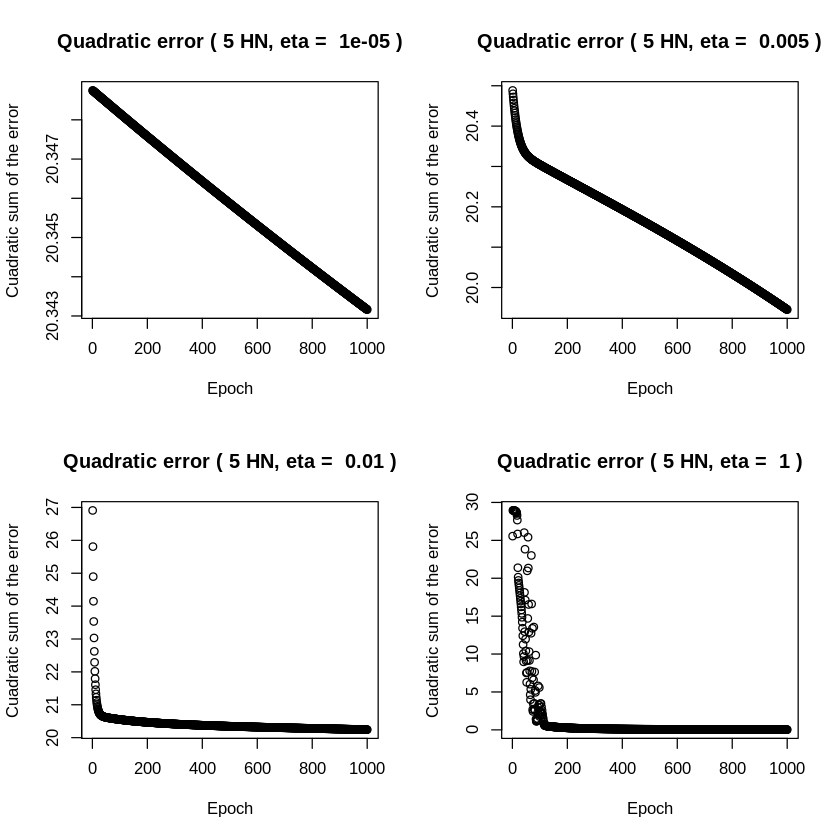

```r
par(mfrow=c(2,2))

plot(backprop_multiple(a, b, h = c(1), epochs = 1000, eta = 0.0001),
     main=paste("Quadratic error ( 1 HN, eta = ", 0.0001, ")"), xlab="Epoch", ylab="Cuadratic sum of the error")
plot(backprop_multiple(a, b, h = c(2), epochs = 1000, eta = 0.0001),
     main=paste("Quadratic error ( 2 HN, eta = ", 0.0001, ")"), xlab="Epoch", ylab="Cuadratic sum of the error")
plot(backprop_multiple(a, b, h = c(5), epochs = 1000, eta = etas[i]),
     main=paste("Quadratic error ( 5 HN, eta = ", 0.0001, ")"), xlab="Epoch", ylab="Cuadratic sum of the error")
plot(backprop_multiple(a, b, h = c(10), epochs = 1000, eta = etas[i]),
     main=paste("Quadratic error ( 10 HN, eta = ", 0.0001, ")"), xlab="Epoch", ylab="Cuadratic sum of the error")
plot(backprop_multiple(a, b, h = c(5), epochs = 1000, eta = 0.00001),
     main=paste("Quadratic error ( 5 HN, eta = ", 0.00001, ")"), xlab="Epoch", ylab="Cuadratic sum of the error")
plot(backprop_multiple(a, b, h = c(5), epochs = 1000, eta = 0.005),
     main=paste("Quadratic error ( 5 HN, eta = ", 0.005, ")"), xlab="Epoch", ylab="Cuadratic sum of the error")
plot(backprop_multiple(a, b, h = c(5), epochs = 1000, eta = 0.01),
     main=paste("Quadratic error ( 5 HN, eta = ", 0.01, ")"), xlab="Epoch", ylab="Cuadratic sum of the error")
plot(backprop_multiple(a, b, h = c(5), epochs = 1000, eta = 1.0),
     main=paste("Quadratic error ( 5 HN, eta = ", 1.0, ")"), xlab="Epoch", ylab="Cuadratic sum of the error")
```

## Add an inertia parameter

Finally, the last part consists in slightly modifying our function so that it can include an inertia parameter as well. This term is going to slightly affect the way the weights are actually being updated. In this code, the main changes with respect to the previous function are commented.

```r
backprop_multiple_inertia <- function(x, b, h = c(5, 5, 5), epochs = 10, eta = 0.1, alpha = 0.1) { #We add the alpha parameter

    x <- cbind(x,rep(1,nrow(x)))
    neurons <- c(ncol(x), h, ncol(b))
    nLayers <- length(neurons)

    values <- list()
    values[[1]] <- x
    values[[nLayers]] <- b

    weights <- list()
    weightsNotUpdated <- list() #Needed to compute the delta weights
    previousWeights <- list() #List to keep the weights of the previous epoch for the inertia term
    for (i in 1:(nLayers-1)) {
        weights[[i]] <- matrix(data = runif(prod(neurons), min = -1, max = 1), nrow = neurons[i+1], ncol = neurons[i])
        previousWeights[[i]] <- 0
    }

    delta <- list()
    errors = c()

    for (j in 1:epochs) {

        for (k in 2:(nLayers)) {
            values[[k]] <- activation(values[[k-1]] %*% t(weights[[k-1]]))
        }

        bout <- values[[nLayers]]
        error <- bout-b
        delta[[nLayers-1]] <- error*bout*(1-bout)

        for (k in (nLayers-2):1) {
            factor <- delta[[k+1]] %*% weights[[k+1]]
            delta[[k]] <- factor * (values[[k+1]]*(1-values[[k+1]]))
        }

        for (k in 1:(nLayers-1)) {
            #This is the main change in this function
            #We add a term depending on the alpha parameter and on the value of the delta weights computed for a previous epoch
            #Let's save the weights before the update to compute the delta weights
            weightsNotUpdated[[k]] <- weights[[k]]
            weights[[k]] <- weights[[k]] - eta * (t(delta[[k]]) %*% values[[k]]) + alpha * (weightsNotUpdated[[k]] - previousWeights[[k]])
            previousWeights[[k]] <- weights[[k]] #Let's save the weights for the inertia term of the next iteration
        }

        errors[j] <- sum((error)^2)

    }

    return(errors)
}
```

Let's finally execute the code of this last function.

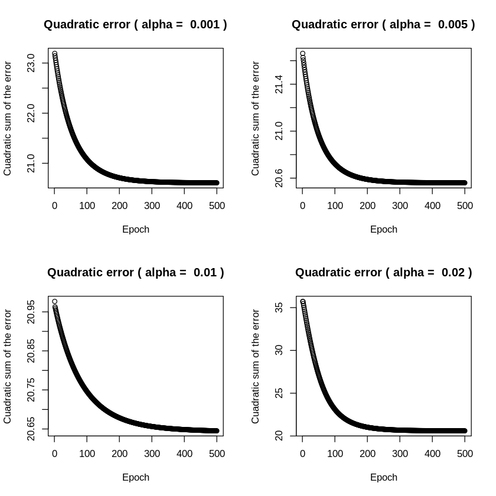

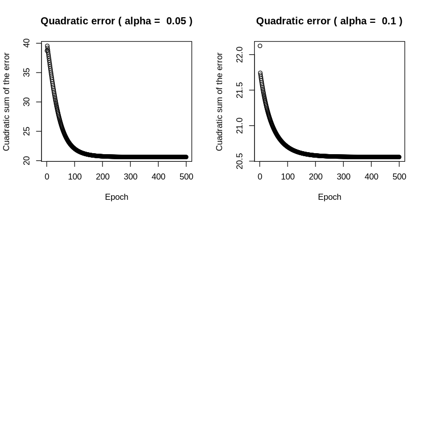

```r
alphas <- c(0.001, 0.005, 0.01, 0.02, 0.05, 0.1) #Let's use different alpha values and plot the error (low values of eat since we are asked to use 500 epochs)
par(mfrow=c(2,2))

for(i in 1:length(alphas)){
    errors <- backprop_multiple_inertia(a, b, h = c(5, 6, 5), epochs = 500, eta = 0.001, alpha = alphas[i])
    plot(errors, main=paste("Quadratic error ( alpha = ", alphas[i], ")"), xlab="Epoch", ylab="Cuadratic sum of the error")
}
```